# Practical Machine Learning Project

fvon

June 4, 2015

These are the files produced during the project of Coursera’s Practical Machine Learning of the Data Science Specialization.

This programming was complete using Windows 7 Professional, R Studio 0.99.441.

## Introduction

The files produced during during this project were submitted as an additional part of the assignment.

Below is the introduction of the exercise:

“Using devices such as Jawbone Up, Nike FuelBand, and Fitbit it is now possible to collect a large amount of data about personal activity relatively inexpensively. These type of devices are part of the quantified self movement. A group of enthusiasts who take measurements about themselves regularly to improve their health, to find patterns in their behavior, or because they are tech geeks. One thing that people regularly do is quantify how much of a particular activity they do, but they rarely quantify how well they do it. In this project, your goal will be to use data from accelerometers on the belt, forearm, arm, and dumbell of 6 participants. They were asked to perform barbell lifts correctly and incorrectly in 5 different ways. More information is available from the website here: http://groupware.les.inf.puc-rio.br/har (see the section on the Weight Lifting Exercise Dataset).”

## Data Sources

The training data for this project may be found at:

https://d396qusza40orc.cloudfront.net/predmachlearn/pml-training.csv

Liewise, the test data is found at:

https://d396qusza40orc.cloudfront.net/predmachlearn/pml-testing.csv

The data for this project comes from Human Activity Recognition (HAR) (http://groupware.les.inf.puc-rio.br/har). We thank them for the use of this data. The use of this data is cited in the Bibliography.

## Project Intended Results

The goal of your project is to predict the manner in which they did the exercise. This is the “classe” variable in the training set. You may use any of the other variables to predict with. You should create a report describing how you built your model, how you used cross validation, what you think the expected out of sample error is, and why you made the choices you did. You will also use your prediction model to predict 20 different test cases.

Your submission should consist of a link to a Github repo with your R markdown and compiled HTML file describing your analysis. Please constrain the text of the writeup to < 2000 words and the number of figures to be less than 5. It will make it easier for the graders if you submit a repo with a gh-pages branch so the HTML page can be viewed online (and you always want to make it easy on graders :-). You should also apply your machine learning algorithm to the 20 test cases available in the test data above. Please submit your predictions in appropriate format to the programming assignment for automated grading. See the programming assignment for additional details.

## Reproduceablity

In order to reproduce the same results, you need a certain set of packages, as well as setting a pseudo random seed equal to the one I used. *Note:To install, for instance, the caret package in R, run this command: install.packages(“caret”)

#### Install Libraries

```r
library(doParallel)
library(caret)
library(dplyr)
```

```r
library(rpart)
library(rpart.plot)
library(RColorBrewer)
library(rattle)
library(randomForest)
library(rattle)
library(corrplot)
```

#### Enable Multi core processing

```r
cl <- makeCluster(detectCores())
registerDoParallel(cl)
```

#### Set random seed

The seed is set to allow for reproducable results

```r
set.seed(2468)
```

## Load Data

#### Training Data URL

```r
trainLOC <- "http://d396qusza40orc.cloudfront.net/predmachlearn/pml-training.csv"
```

#### Testing Data URL

```r
testLOC <- "http://d396qusza40orc.cloudfront.net/predmachlearn/pml-testing.csv"
```

#### Data directly into memory

```r
train <- read.csv(url(trainLOC), na.strings=c("NA","#DIV/0!",""))
test <- read.csv(url(testLOC), na.strings=c("NA","#DIV/0!",""))

dim(train)
```

```
## [1] 19622   160
```

#### Remove Columns with sunstantial NA’s

```r
#5 classes (sitting-down, standing-up, standing, walking, and sitting) collected on 8 hours of activities of 4 healthy subjects

na_test = sapply(train, function(x) {sum(is.na(x))})
table(na_test)
```

```
## na_test
##     0 19216 19217 19218 19220 19221 19225 19226 19227 19248 19293 19294
##    60    67     1     1     1     4     1     4     2     2     1     1
## 19296 19299 19300 19301 19622
##     2     1     4     2     6
```

```r
bad_columns = names(na_test[na_test>=19000])
train = train[, !names(train) %in% bad_columns]
dim(train)
```

```
## [1] 19622    60
```

#### Remove colums that do not help with prediction in the Train data set

```r
train <- select(train, `roll_belt`:`classe`  )

dim(train)
```

```
## [1] 19622    53
```

#### Partioning the training set

Partioning Train data set into two data sets, 60% for TrainTrain, 40% for TrainTest:

```r
inTrain <- createDataPartition(y=train$classe, p=0.6, list=FALSE)

traintrain <- train[inTrain,]
traintest <- train[-inTrain,]
dim(traintrain)
```

```
## [1] 11776    53
```

#### Create Model

```r
set.seed(2468)

controlRanfor <- trainControl(method="cv", 5)

model <- randomForest(classe~.,data=traintrain, method="rf", trControl=controlRanfor, ntree=250)

model
```

```
##
## Call:
##  randomForest(formula = classe ~ ., data = traintrain, method = "rf",      trControl = controlRanfor, ntree = 250)
##                Type of random forest: classification
##                      Number of trees: 250
## No. of variables tried at each split: 7
##
##         OOB estimate of  error rate: 0.64%
## Confusion matrix:
##      A    B    C    D    E class.error
## A 3343    4    0    1    0 0.001493429
## B   11 2264    4    0    0 0.006581834
## C    0   13 2037    4    0 0.008276534
## D    0    0   29 1900    1 0.015544041
## E    0    0    1    7 2157 0.003695150
```

### Testing the model

The model is tested using the other portion of the training data

```r
set.seed(2468)

predictRanfor <- predict(model, traintest)

confusionMatrix(traintest$classe, predictRanfor)
```

```
## Confusion Matrix and Statistics
##
##           Reference
## Prediction    A    B    C    D    E
##          A 2231    1    0    0    0
##          B    4 1511    3    0    0
##          C    0   10 1358    0    0
##          D    0    0   11 1274    1
##          E    0    0    1    1 1440
##
## Overall Statistics
##
##                Accuracy : 0.9959
##                  95% CI : (0.9942, 0.9972)
##     No Information Rate : 0.2849
##     P-Value [Acc > NIR] : < 2.2e-16
##
##                   Kappa : 0.9948
##  Mcnemar's Test P-Value : NA
##
## Statistics by Class:
##
##                      Class: A Class: B Class: C Class: D Class: E
## Sensitivity            0.9982   0.9928   0.9891   0.9992   0.9993
## Specificity            0.9998   0.9989   0.9985   0.9982   0.9997
## Pos Pred Value         0.9996   0.9954   0.9927   0.9907   0.9986
## Neg Pred Value         0.9993   0.9983   0.9977   0.9998   0.9998
## Prevalence             0.2849   0.1940   0.1750   0.1625   0.1837
## Detection Rate         0.2843   0.1926   0.1731   0.1624   0.1835
## Detection Prevalence   0.2845   0.1935   0.1744   0.1639   0.1838
## Balanced Accuracy      0.9990   0.9958   0.9938   0.9987   0.9995
```

```r
set.seed(2468)

Accu <- postResample(predictRanfor,traintest$classe)

Accu
```

```
##  Accuracy     Kappa
## 0.9959215 0.9948408
```

```r
set.seed(2468)

oouosamperr <- 1 - as.numeric(confusionMatrix(traintest$classe, predictRanfor)$overall[1])

oouosamperr
```

```
## [1] 0.004078511
```

### Prediction of Test Data

During this process we clean the data in a similar fashon as the training data. The previously developed model is then assessed using the the data previously put aside and not examined.

```r
na_test1 = sapply(test, function(x) {sum(is.na(x))})
table(na_test1)
```

```
## na_test1
##   0  20
##  60 100
```

```r
bad_columns = names(na_test1[na_test1>=19000])
train = test[, !names(test) %in% bad_columns]
dim(test)
```

```
## [1]  20 160
```

```r
test <- select(test, `roll_belt`:`magnet_forearm_z`  )
dim(test)
```

```
## [1]  20 152
```

```r
set.seed(2468)

answers<-(predict(model, newdata=test))

answers
```

```
##  1  2  3  4  5  6  7  8  9 10 11 12 13 14 15 16 17 18 19 20
##  B  A  B  A  A  E  D  B  A  A  B  C  B  A  E  E  A  B  B  B
## Levels: A B C D E
```

### Create files for testing

```r
setwd("~/R/answers")

pml_write_files = function(x){
  n = length(x)
  for(i in 1:n){
    filename = paste0("problem_id_",i,".txt")
    write.table(x[i],file=filename,quote=FALSE,row.names=FALSE,col.names=FALSE)
  }
}

pml_write_files(answers)
```

## Appendix

Figure 1. Correlation Matrix of variable in the trainig set

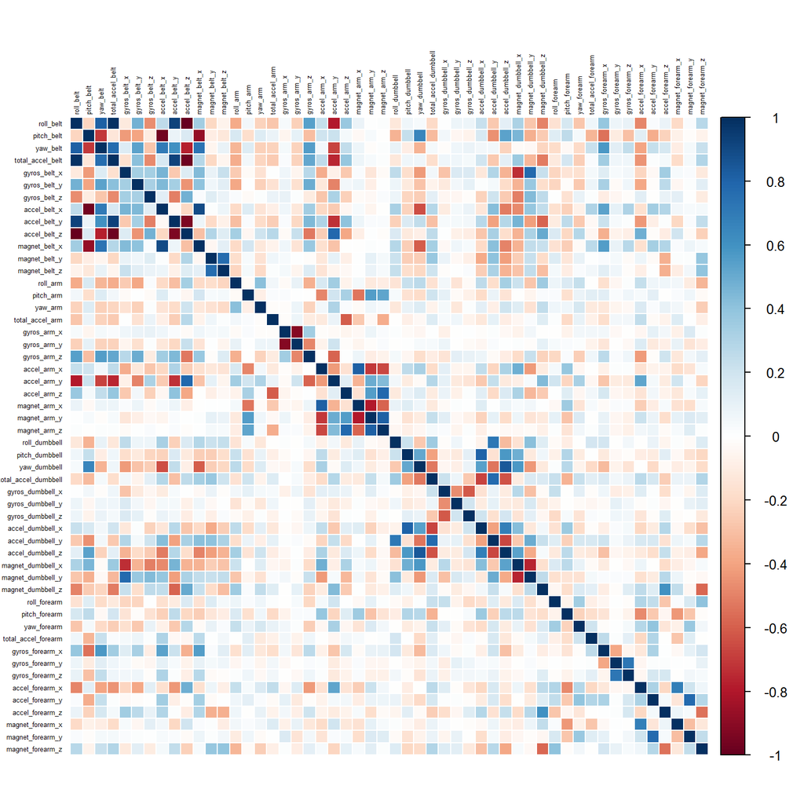

```r
traincor <- select(traintrain, `roll_belt`:`magnet_forearm_z`  )
corrplot(cor(traincor, use="pairwise.complete.obs"), method="shade",shade.col=NA, tl.col="black", tl.cex=0.4, tl.srt=90)
```

## Bibliography

Ugulino, W.; Cardador, D.; Vega, K.; Velloso, E.; Milidiu, R.; Fuks, H. Wearable Computing: Accelerometers’ Data Classification of Body Postures and Movements. Proceedings of 21st Brazilian Symposium on Artificial Intelligence. Advances in Artificial Intelligence - SBIA 2012. In: Lecture Notes in Computer Science. , pp. 52-61. Curitiba, PR: Springer Berlin / Heidelberg, 2012. ISBN 978-3-642-34458-9. DOI: 10.1007/978-3-642-34459-6_6.

Read more: http://groupware.les.inf.puc-rio.br/har#ixzz3c7PS19IW